# Clusterization of Customer Segments (Part I)

### Outliers detection

Even though I work with clean dataset, it is still very important to check for outliers in the data. These are too high or low values based on the interquartile range of the attribute. I picked the reviewed attributes on random choice. The detection of outliers is crucial, because if there are identified ones, eventually the final ML clustering model should be picked with such consideration. I used boxplots to quickly review.

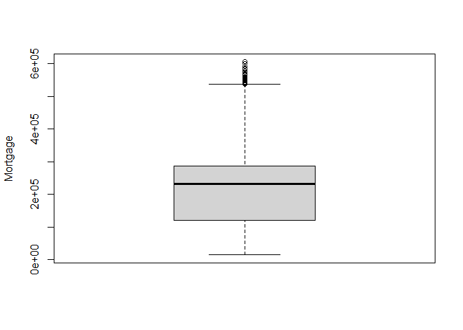

```r
boxplot(raw$MortageVolume, ylab = "Mortgage")
```

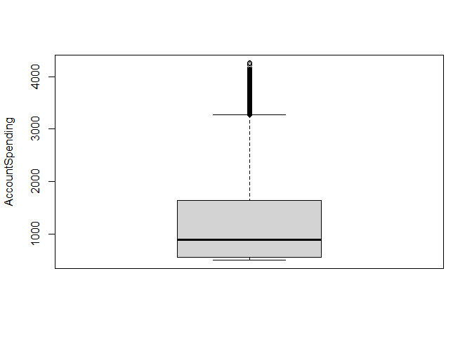

```r
boxplot(raw$AccountSpending, ylab= "AccountSpending")
```

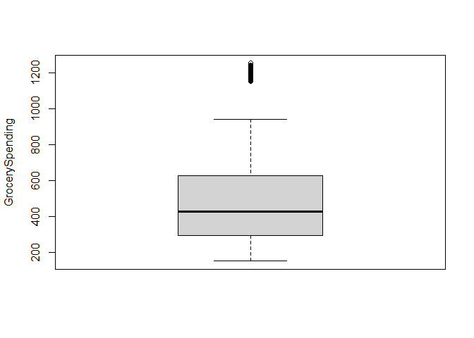

```r
boxplot(raw$GrocerySpending, ylab= "GrocerySpending")
```

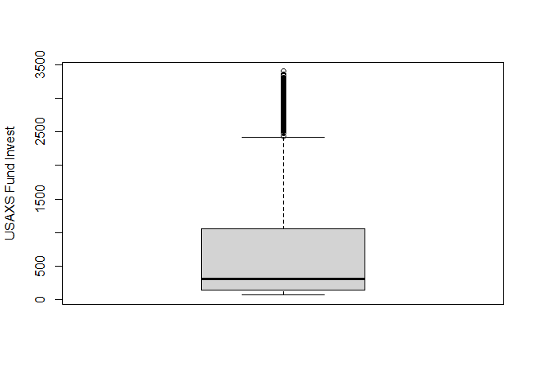

```r
boxplot(raw$USAXSFundInvest, ylab= "USAXS Fund Invest")
```

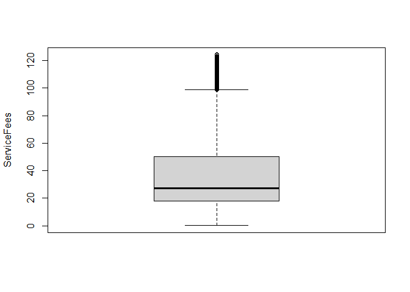

```r
boxplot(raw$ServiceFees, ylab= "ServiceFees")
```

In the dataset containing the behavioral characteristics of customers, anomalies can be found in some variables. If this data is not removed, but kept in order to preserve the information, then it is good to choose a clustering model, which copes better with the treatment of anomalies. For example, k-means is quite sensitive to outliers and it is possible that K-medoids is more suitable.